# [Lecture Note] Data Visualization

### Piechart

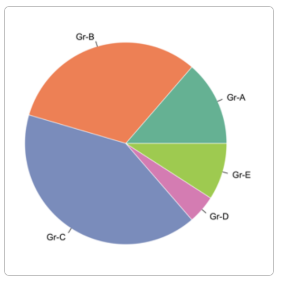

A piechart is a circle divided into sectors that each represent a proportion of the whole.

### Dendrogram

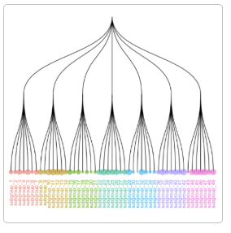

A dendrogram (or tree diagram) is a network structure. It is constituted of a root node that gives birth to several nodes connected by edges or branches. The last nodes of the hierarchy are called leaves.

### Circular packing

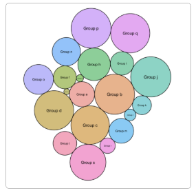

Circular packing or circular treemap allows to visualize a hierarchic organization. It is an equivalent of a treemap or a dendrogram, where each node of the tree is represented as a circle and its sub-nodes are represented as circles inside of it.

### Waffle Chart

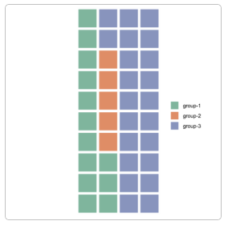

A Waffle Chart visually represents categorical data through a grid of small squares, resembling a waffle. Each category is assigned a unique color, and the number of squares allocated to each category corresponds to its proportional share of the total data count.

## Evolution

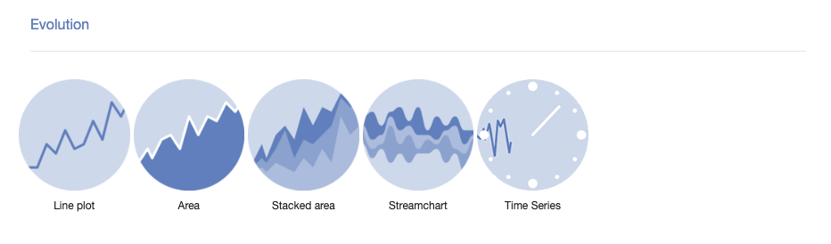

### Line chart

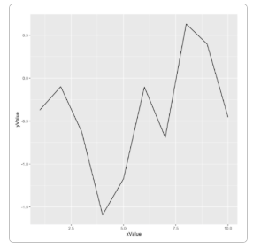

Line chart is similar to to a connected scatterplot that is almost the same thing, but each observation is represented as a dot.

### Area chart

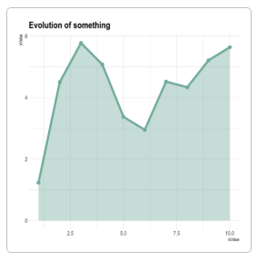

An area chart represents the evolution of a numeric variable. It is very close to a line chart. A line chart is the same but doesn’t fill the surface between the line and the X axis. A connected scatterplot is almost the same thing, but each observation is represented as a dot.

### Stacked area chart

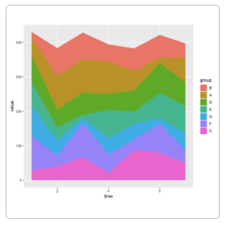

A stacked area chart displays the evolution of a numeric variable for several groups. It is very close to an area chart.

### Streamgraph

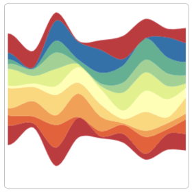

A streamgraph is a type of stacked area chart. It represents the evolution of a numeric variable for several groups. Areas are usually displayed around a central axis, and edges are rounded to give a flowing shape.

### Time series

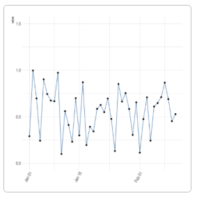

Time series aim to study the evolution of one or several variables through time.

## Map

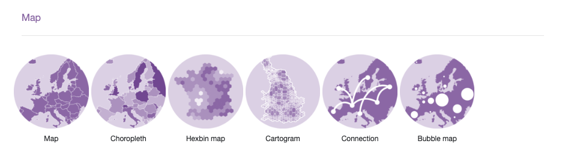

### Map chart

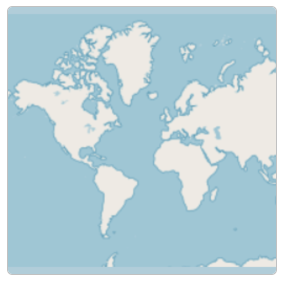

Map chart, It explains how to build static and interactive maps based on different input data, but does not explain how to plot data on it.

### Choropleth map

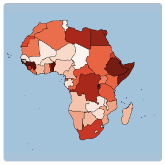

A choropleth map displays divided geographical areas or regions that are coloured in relation to a numeric variable.

### Hexbin map

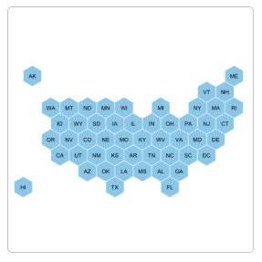

A hexbin map refers to two different concepts. It can be based on a geospatial object where all regions of the map are represented as hexagons.

### Cartogram

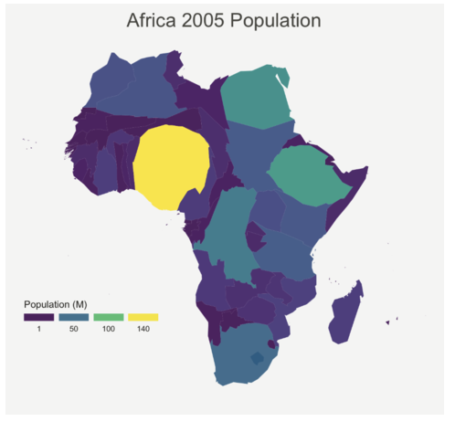

A cartogram is a map in which the geometry of regions is distorted in order to convey the information of an alternate variable. The region area will be inflated or deflated according to its numeric value.

### Connection map

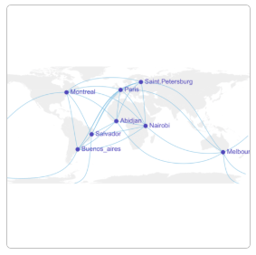

A connection map shows the connections between several positions on a map. The link between 2 locations is usually drawn using great circle: the shortest route between them. It results in a rounded line that gives a really pleasant look to the map.

### Bubble map

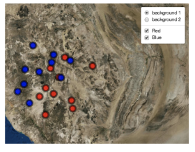

Bubble map, this section is dedicated to map with markers displayed on top of it. These markers can be circles with size proportional to a numeric value, resulting in a bubble map.

## Flow

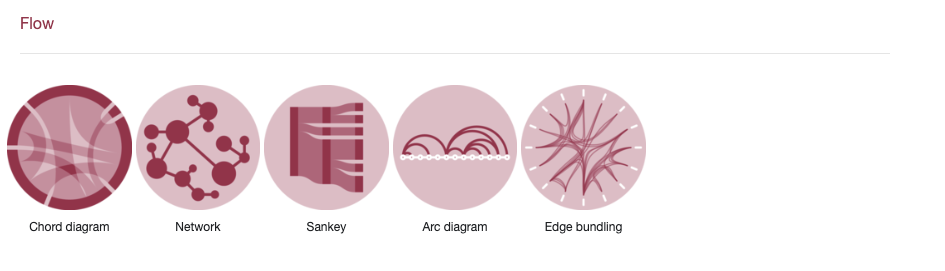

### Chord diagram

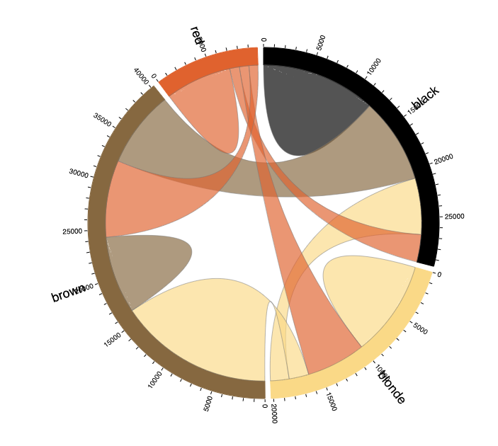

A Chord diagram allows to study flows between a set of entities. Entities (nodes) are displayed all around a circle and connected with arcs (links).

### Network diagrams

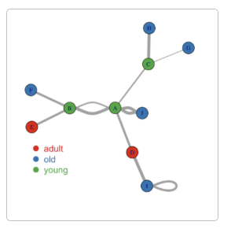

Network diagrams (or Graphs) show interconnections between a set of entities. Each entity is represented by a Node (or vertice). Connections between nodes are represented by links (or edges).

### Sankey diagram

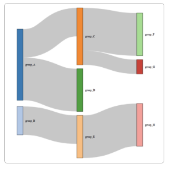

A Sankey diagram allows to study flows. Entities (nodes) are represented by rectangles or text.

### Arc diagram

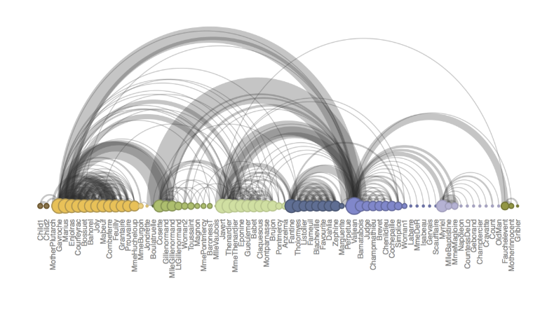

An arc diagram is a special kind of network graph. It is consituted by nodes that represent entities and by links that show relationships between entities. In arc diagrams, nodes are displayed along a single axis and links are represented with arcs.

### Hierarchical edge bundling

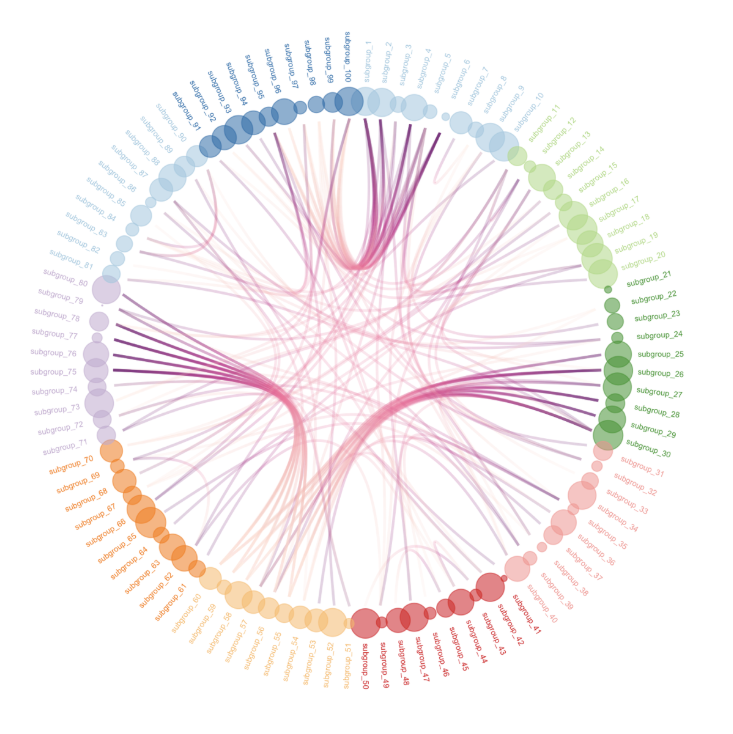

Hierarchical edge bundling allows to visualize adjacency relations between entities organized in a hierarchy. The idea is to bundle the adjacency edges together to decrease the clutter usually observed in complex networks.

# House Keeping